# Type-II Error Simulation

Visualizations of the results can be found here: [Tableau Dashboard](https://public.tableau.com/profile/richard2368#!/vizhome/ThesisVisualizations/PowerType-IErrorAcrossSampleSizesDashboard)

The purpose of this report is to outline in detail the analysis procedure used to generate the results when the alternate hypothesis is true. The outcome measures include:

1. Type-II error rate
2. Power
3. Experimental and control means
4. Experimental and control standard deviations

The large amount of data makes it challenging to understand because there would be too many visualizations to look through. For this reason the table will be exported and a Tableau dashboard will be created to enable quick filtering and comparisons.

### Using the “here” package

```r
# install.packages("here")
library(here)
library(xtable)
here()

load(here("Type_II_Error_Simulation_Data.RData"))
```

### Begin by loading in all of the packages and libraries

```r
#Packages and Libraries needed to run the code

#install.packages("XLConnect")
#install.packages("data.table")
#install.packages("gdata")
#install.packages("markdown")
#install.packages("xlsx")
#install.packages("car")
#install.packages("lmerTest")
#install.packages("MESS")
#install.packages("pracma")
#install.packages("fBasics")
#install.packages("corrr")
# install.packages("lsr")
# install.packages("lme4")
# install.packages('dplyr')
# install.packages("pwr2")
# install.packages("agricolae")
# install.packages("multcomp")
# install.packages("lsmeans")
# install.packages("pwr")
# install.packages("stargazer")
# install.packages("apaTables")
library(apaTables)
library(stargazer)
library(multcomp)
library(lsmeans)
library(agricolae)
# library(pwr2)
library(lme4)
library(pwr)
library(gridExtra)
# library(lsr)
# library(tidyr)
library(reshape2)
# library(pracma)
# library(MESS)
library(data.table)
library(lmerTest)
library(car)
library(ggplot2)
# library(XLConnect)
library(gdata)
library(markdown)
library(xlsx)
library(dplyr)
library(plyr)
library(gtools)
library(dplyr)
library(boot)
library(broom)
library(knitr)
options(scipen=999) #stopping scientific notation
```

### Common variables

```r
# path = "Y:/Archived Studies/Richard - 10-2018/Code/Kits EEG Data/Simulation/"
output_path = "C:/Users/rjobrien/Desktop/Thesis Code/Output/"

# plot_path = "Y:/Archived Studies/Richard - 10-2018/Code/Kits EEG Data/Simulation/Plots/"

# sample_size = unlist(seq(10, 140, 10))
sample_size = 50

effect_size <- seq(.1, 1, by = .1)

simulation_number = 1000
```

### Mixed anova power function

```r
# function ---------------------------------------------------------------
anova.pwr.mixed <- function(data, Formula, n, m, rho, n.needed=FALSE) {
  require(stringr)
  Formula <- formula(paste(Formula, "+Error(group)"))               # aov formula
  x <- summary(aov(Formula, data))          # aov model
  terms <- c(rownames(x[[1]][[1]]), rownames(x[[2]][[1]])) # terms in model
  terms <- str_pad(terms, max(nchar(terms)), "right")      # fix typography

  pwr <- function(n) {
    k <- length(unique(study$group))          # n groups
    sigma <- mean(data$SD)                    # sigma
    data$n <- n                               # n per group
    N <- sum(with(data, tapply(n,group,unique))) # total N
    x <- summary(aov(Formula, data))          # aov model
    var_b <- x[[1]][[1]][[2]] / (k*m)         # SS between
    var_w <- x[[2]][[1]][[2]] / (k*m)         # SS within
    f_between <- sqrt(var_b / sigma^2)        # f between
    f_within <- sqrt(var_w / sigma^2)         # f within

    # Degrees of freedom ------------------------------------------------------
    df1_b <- x[[1]][[1]][[1]]              # df model between
    df1_w <- x[[2]][[1]][[1]]              # df model within
    df1 <- c(df1_b, df1_w)
    df2_b <- N-1-sum(df1_b)                # df error between
    df2_w <- (N*m-1) - (N-1) - sum(df1_w)  # df error within

    # Power Between -----------------------------------------------------------------
    lambda <- N * (m/(1+(m-1)*rho)) * f_between^2        # lambda between
    F_critical <- qf(0.05,df1_b,df2_b, lower.tail=FALSE) # F critical between
    power_b <- pf(F_critical, df1_b, df2_b, lambda, lower.tail=FALSE) # power between

    # Power Within -----------------------------------------------------------------
    lambda <- (N * m * f_within^2) / (1 - rho)           # lambda within
    F_critical <- qf(0.05,df1_w,df2_w, lower.tail=FALSE) # F critical within
    power_w <- pf(F_critical, df1_w, df2_w, lambda, lower.tail=FALSE) # power within
    c("b" = power_b, "w" = power_w)
  }

  # Get n for desired power -------------------------------------------------
  power <- pwr(n) # get powr for 'n'
  if(n.needed) {
    n_needed <- rep(NA, length(power)) # pre-create object
    # loop til desired power is found
    for(i in 1:length(power)) {
      n2 <- 5
      while(pwr(n2)[i] < 0.8) n2 <- n2+1
      n_needed[i] <- n2
    }
  } else n_needed <- NA


  # output ------------------------------------------------------------------
  out <- data.frame(terms, "power" = round(power, 3),
                    "n.needed" = n_needed) # n per group
  names(out)[1] <- str_pad("Terms", max(nchar(terms)), "right")
  out
}
```

### Population standard deviation and effect size voltage differences

```r
#First: find the standard deviation of the population dataset
print(paste0("Population Standard Deviation: ", round(sd(ERP2_PZ$PZ), 3)))
```

```
## [1] "Population Standard Deviation: 5.469"
```

```r
#Second: Build a function that calculates the value needed for each effect size
value = function(d, data){
  return(d * sd(data))
}



effect_size = seq(.0, 1, by = .1)

sample_size = unlist(seq(10, 100, 10))




differences = data.frame()
#All effect sizes added
for (e in effect_size){
  differences = rbind(differences, cbind(e, value(e, ERP2_PZ$PZ)))
}

colnames(differences) = c("Effect Size", "Difference")

kable(differences, caption = "Effect Size Differences")
```

Effect Size Differences

| Effect Size | Difference |
| --- | --- |
| 0.0 | 0.0000000 |
| 0.1 | 0.5469174 |
| 0.2 | 1.0938347 |
| 0.3 | 1.6407521 |
| 0.4 | 2.1876694 |
| 0.5 | 2.7345868 |
| 0.6 | 3.2815041 |
| 0.7 | 3.8284215 |
| 0.8 | 4.3753388 |
| 0.9 | 4.9222562 |
| 1.0 | 5.4691735 |

### Simulation Procedure Type-II Error

#### Dataset production

1. Using the sample size, randomly subset samples (ERP waveforms) from the population dataset. The subset of the data drawn from the population dataset without replacement is twice the sample size selected.
2. To create the control condition, randomly subset a number of samples from the subsetted data set equal to the sample size.
3. To create the experimental conditions data set, remove the control conditions data from the subsetted dataset to leave the remaining samples
4. Add the calculated effect size difference to each data point
5. Subsetting out the time window (300-500 ms) in which we believe the P3 amplitude will fall within

#### Combining all of the peak-picking methodologies data together into one large dataframe

9. Label and combine all of the peak-picking methodologies data together

#### Means

10. Calculating means of each peak-picking methodology by condition and generating a new dataset

#### Conducting an ANOVAs

11. Perform an ANOVA with the P3 amplitude as a dependent variable and fixed effects with condition and peak-picking methodology
12. Performing an ANOVA for each peak-picking methodology with the P3 amplitude as a dependent variable and a fixed effect of condition. Store the p-values in a new dataframe, and use these values later to calculate the type-I error rate.

#### Post-Hoc testing

13. Perform a Tukey’s HSD post-hoc test on the anova model with the condition and peak-picking methodology fixed effects
14. Generate a new dataset containing the p-values from the Tukey HSD post-hoc test

#### Calculate the type-II error rate

15. Calculate the type-II error rate and power.

```r
set.seed(1234)

peak_pvalue_dist = data.frame()

simulation_number = 1000
numTests <- simulation_number  #number of t-test
alphaSet = c(0.05)  #set of alpha values to test
sigTests <- data.frame()
pvalue_dist = data.frame()
allmeans = data.frame()
post_hoc_results_temp1 = data.frame()
post_hoc_results_temp2 = data.frame()
post_hoc_results_condition = data.frame()
post_hoc_results_method = data.frame()
all.peak.result = data.frame()
all.mean.result = data.frame()
all.adaptive.mean.result = data.frame()


sample_size = unlist(seq(10, 100, 10))
# sample_size = 10
effect_size = seq(0.1, 1, by = .1)
# effect_size = 0.1

for (s in sample_size){


  for (e in effect_size){

    #Starting the simulation
    counter <- 1 #keeps track of row numbers in the output table
    for (i in 1:numTests) {

        #Sample the necessary number of sample from the popultion dataset (2 times: one for each condition)
        temp = ERP2_PZ[ERP2_PZ$sample %in% sample(unique(ERP2_PZ$sample),
                                        size = s * 2,
                                        replace = FALSE), ]

        #Checking to see if we subsetted 80 unique samples
        # length(unique(temp$sample))

        #Then randomly sample the control condition from the temp data
        control_condition = temp[temp$sample %in% sample(unique(temp$sample),
                                                size = s,
                                                replace = FALSE), ]

        #Checking to see if we subsetted half the number unique samples from temp
        # length(unique(control_condition$sample))

        control_condition$condition = "control"

        #Remove those samples from the original dataset, and the remaining trials become the experimental condition
        experimental_condition = temp[!temp$sample %in% control_condition$sample, ]

        #Checking to see if we remove the unique samples used for the control condition
        length(unique(experimental_condition$sample))

        experimental_condition$condition = "experimental"

        #Increasing the voltage of the experimental condition to make the null hypothesis false
        #Do this by adding a value calculated by using the effect size and pooled standard deviation of
        #the population dataset
        experimental_condition$PZ = experimental_condition$PZ + value(e, ERP2_PZ$PZ)

        #Combining the experimental and control conditions together
        conditions_combined = rbind(experimental_condition, control_condition)

        #Subsetting out the time window we expect the P3 to fall within
        data = conditions_combined[(conditions_combined$TIME >= 300 &
                                               conditions_combined$TIME <= 500),]


        #======================================================================================#
        #Generating peak and mean amplitudes
        #======================================================================================#
        #Calculating the peak amplitude
        peak_amps_erp = setDT(data)[, .SD[which.max(PZ)], by = list(sample, condition)]

        peak_amps_erp = peak_amps_erp[, c("sample", "condition", "PZ")]

        peak_amps_erp$method = "Peak Amplitude"


        #======================================================================================#
        #Calculating the adaptive mean amplitude

        #This way seems to work if you want to use more than one index
        mean_amps_erp1 = rbind(setDT(data)[, .SD[c(which.max(PZ) - 1)], by = list(sample, condition)],
                               setDT(data)[, .SD[c(which.max(PZ) - 2)], by = list(sample, condition)],
                               setDT(data)[, .SD[c(which.max(PZ) - 3)], by = list(sample, condition)],
                               setDT(data)[, .SD[c(which.max(PZ) - 4)], by = list(sample, condition)])


        mean_amps_erp = setDT(data)[, .SD[c(
                                       which.max(PZ),
                                       which.max(PZ) + 1,
                                       which.max(PZ) + 2,
                                       which.max(PZ) + 3,
                                       which.max(PZ) + 4
                                       # which.max(PZ) + 5
                                       )],
                                    by = list(sample, condition)]

        mean_amps_erp = na.omit(rbind(mean_amps_erp, mean_amps_erp1))

        mean_amps_erp = mean_amps_erp[, c("sample", "condition", "PZ")]

        mean_amps_erp = setDT(mean_amps_erp)[ , mean(PZ), by = list(sample, condition)]

        colnames(mean_amps_erp) = c("sample", "condition", "PZ")

        mean_amps_erp$method = "Adaptive Mean Amplitude"

        #======================================================================================#
        #Calculating the mean amplitude
        mean2_amps_erp = aggregate(. ~ sample + condition, data, FUN = mean)

        mean2_amps_erp = na.omit(mean2_amps_erp)

        mean2_amps_erp = mean2_amps_erp[, c("sample", "condition", "PZ")]

        mean2_amps_erp$method = "Mean Amplitude"


        #======================================================================================#
        #Combined all 3 datasets together
        #======================================================================================#

        peak_methods = rbind(peak_amps_erp, mean_amps_erp, mean2_amps_erp)

        #======================================================================================#
        #Calculating the p-values for the anova
        #======================================================================================#
        test.result = lm(PZ ~ condition*method, peak_methods)

        #Putting together all of the data into a dataframe
        sigTests[counter, 1] = anova(test.result)$'Pr(>F)'[1]
        sigTests[counter, 2] = anova(test.result)$'Pr(>F)'[2]
        sigTests[counter, 3] = s #sample size
        sigTests[counter, 4] = e #effect size
        sigTests[counter, 5] = i #simulation number

        #Calculating all of the means used in the linear model
        means = aggregate(PZ ~ condition + method, peak_methods, FUN = mean)
        means[, 4] = s #sample size
        means[, 5] = e #effect size
        means[, 6] = i #simulation number

        allmeans = rbind(allmeans, means)

        #======================================================================================#
        #Calculating the p-values for the post-hoc test
        #======================================================================================#
        post_hoc_results = TukeyHSD(aov(PZ ~ condition*method, peak_methods)) #Confidence level is 95%

        post_hoc_results_temp1 = as.data.frame(post_hoc_results[1])
        post_hoc_results_temp1[, 5] = s #sample size
        post_hoc_results_temp1[, 6] = e #effect size
        post_hoc_results_temp1[, 7] = i #simulation number

        post_hoc_results_temp2 = as.data.frame(post_hoc_results[2])
        post_hoc_results_temp2[, 5] = s #sample size
        post_hoc_results_temp2[, 6] = e #effect size
        post_hoc_results_temp2[, 7] = i #simulation number

        post_hoc_results_condition = rbind(post_hoc_results_condition, post_hoc_results_temp1)
        post_hoc_results_method = rbind(post_hoc_results_method, post_hoc_results_temp2)


        #======================================================================================#
        #Calculating the p-values for each methodology to see if there's a condition effect
        #======================================================================================#
        peak.result = anova(lm(PZ ~ condition, peak_methods[peak_methods$method == "Peak Amplitude", ]))
        peak.result = peak.result[1, ]
        peak.result[, 6] = s #sample size
        peak.result[, 7] = e #effect size
        peak.result[, 8] = i #simulation number


        adaptive.mean.result = anova(lm(PZ ~ condition, peak_methods[peak_methods$method == "Adaptive Mean Amplitude", ]))
        adaptive.mean.result = adaptive.mean.result[1, ]
        adaptive.mean.result[, 6] = s #sample size
        adaptive.mean.result[, 7] = e #effect size
        adaptive.mean.result[, 8] = i #simulation number

        mean.result = anova(lm(PZ ~ condition, peak_methods[peak_methods$method == "Mean Amplitude", ]))
        mean.result = mean.result[1, ]
        mean.result[, 6] = s #sample size
        mean.result[, 7] = e #effect size
        mean.result[, 8] = i #simulation number


        #Rbinding to larger dataframe
        all.peak.result = rbind(all.peak.result, peak.result)
        all.adaptive.mean.result = rbind(all.adaptive.mean.result, adaptive.mean.result)
        all.mean.result = rbind(all.mean.result, mean.result)

        counter <- counter + 1 #move to the next row
    }


    pvalue_dist = rbind(pvalue_dist, sigTests)

  }
}

#Setting column names
colnames(pvalue_dist)[1:5] = c("condition", "method", "sample_size", "effect_size", "sample")
colnames(allmeans)[4:6] = c("sample_size", "effect_size", "sample")
colnames(post_hoc_results_method)[5:7] = c("sample_size", "effect_size", "sample")
colnames(post_hoc_results_condition)[5:7] = c("sample_size", "effect_size", "sample")
colnames(all.peak.result)[6:8] = c("sample_size", "effect_size", "sample")
colnames(all.adaptive.mean.result)[6:8] = c("sample_size", "effect_size", "sample")
colnames(all.mean.result)[6:8] = c("sample_size", "effect_size", "sample")


#Converting the method into a column and removing unnecessary numeric values
post_hoc_results_method$method = gsub('[[:digit:]]+', "", rownames(post_hoc_results_method))
rownames(post_hoc_results_method) = NULL

post_hoc_results_condition$condition = gsub('[[:digit:]]+', "", rownames(post_hoc_results_condition))
rownames(post_hoc_results_condition) = NULL

#I DON'T THINK THIS IS USEFUL
pvalue_dist$condition_typeIIerror = ifelse(pvalue_dist$condition > 0.05, 1, 0)
pvalue_dist$method__typeIIerror = ifelse(pvalue_dist$method > 0.05, 1, 0)
pvalue_dist = na.omit(pvalue_dist)


#Combining the individual method results together
all.peak.result$method = "peak methodology"
all.adaptive.mean.result$method = 'adapative mean methodology'
all.mean.result$method = 'mean methodology'
all.results = rbind(all.peak.result, all.adaptive.mean.result, all.mean.result)

#Finding the type II error and power
all.results$typeIIerror = ifelse(all.results$`Pr(>F)` > 0.05, 1, 0)
all.results2 = aggregate(. ~ sample_size + effect_size + method, all.results, FUN = sum)
all.results2$typeIIerror = (all.results2$typeIIerror/numTests)*100
all.results2$power = 100 - all.results2$typeIIerror


#Calculating the type II error and power
sigTests_typetwo = aggregate(. ~ sample_size + effect_size, pvalue_dist, FUN =sum)
sigTests_typetwo$condition_power = numTests - sigTests_typetwo$condition_typeIIerror
sigTests_typetwo$method_power = numTests - sigTests_typetwo$method__typeIIerror
```

### Exporting data to visualize in Tableau

```r
write.xlsx(post_hoc_results_condition, paste0(output_path, "Condition post-hoc results.xlsx"))

write.xlsx(post_hoc_results_method, paste0(output_path, "Method post-hoc results.xlsx"))

write.xlsx(sigTests_typetwo, paste0(output_path, "Sigtest type II.xlsx"))

write.xlsx(all.results, paste0(output_path, "Type-II Error P-value distribution.xlsx"))

write.xlsx(allmeans, paste0(output_path, "Mean value by simulation.xlsx"))
```

### Generating a table containing all results that will be exported to generate visualization in Tableau

```r
#TABLE 3A -TYPE II ERROR AND POWER TABLE
table3 = all.results2[, c("method", "sample_size", "effect_size", "typeIIerror", "power")]


#COMBINE TABLE 3 WITH THE MEANS AND STANDARD DEVIATIONS
one_table = merge(dcast(allmeans, method + sample_size + effect_size ~ condition, fun = mean, value.var = "PZ"),
                  dcast(allmeans, method + sample_size + effect_size ~ condition, fun = sd, value.var = "PZ"),
                  by = c("method", "sample_size", "effect_size"))

#Changing the column names
colnames(one_table) = c("method",
                        "sample_size",
                        "effect_size",
                        "control_means",
                        "experimental_means",
                        "control_sd",
                        "experimental_sd")

#THIS MAY NOT BE NEEDED IN THE FUTURE
table3$method = as.factor(table3$method)
levels(table3$method) = c("Adaptive Mean Amplitude", "Mean Amplitude", "Peak Amplitude")

one_table = merge(one_table, table3, by = c("method", "sample_size", "effect_size"))



write.xlsx(one_table, paste0(path, "Type-II Error Simulation Results.xlsx"))

#Sorting the data
one_table = one_table[order(one_table$method, one_table$sample_size), ]

kable(one_table)
```

[output not shown]

# Analyzing the Means

## MEAN - ANOVA

We would be an interaction between condition and effect size and no interaction between condition and methodology

Outcomes:

## MEAN - POST-HOC CONDITION

```r
#Post-hoc test with just method comparisons
#These statistically significant differences make sense and are in line with what we'd expect to see
post_hoc_model2 = emmeans(
  model,
  pairwise ~ condition,
  adjust = "tukey",
  mode = "satterthwaite"
  ) %>%
  summary(infer = TRUE, type = "response")
```

```
## NOTE: Results may be misleading due to involvement in interactions
```

```r
kable(post_hoc_model2[2], #Printing only the comparisons
      caption = "Post-Hoc Condition Comparisons",
      digits = 3)
```

Post-Hoc Condition Comparisons

| contrast | estimate | SE | df | lower.CL | upper.CL | t.ratio | p.value |
| --- | --- | --- | --- | --- | --- | --- | --- |
| control - experimental | -3.002 | 0.001 | 599967 | -3.005 | -2.999 | -2153.162 | 0 |

#### Post-hoc condition visualization

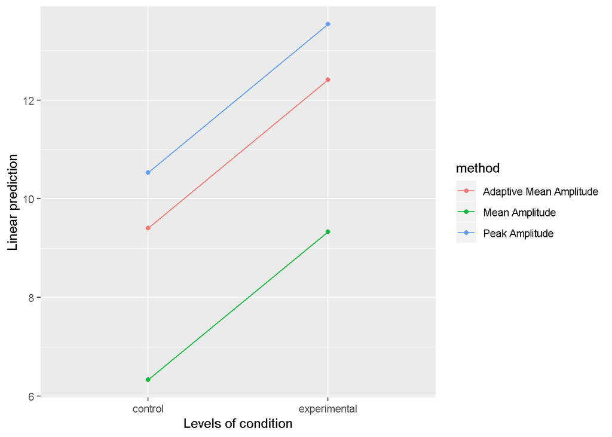

```r
#=========================================#
#POST-HOC TUKEY TESTS AND VISUALIZATIONS
#=========================================#
#This graph indicates that all sample sizes produce similar results for each peak-picking methodology
emmip(model, method ~ condition) #No interaction between these three variables
```

## MEAN - POST-HOC EFFECT SIZE

```r
#Post-hoc test with just method comparisons
#These statistically significant differences make sense and are in line with what we'd expect to see
post_hoc_model2 = emmeans(
  model,
  pairwise ~ effect_size,
  adjust = "tukey",
  mode = "satterthwaite"
  ) %>%
  summary(infer = TRUE, type = "response")
```

```
## NOTE: Results may be misleading due to involvement in interactions
```

```r
kable(post_hoc_model2[2], #Printing only the comparisons
      caption = "Post-Hoc Effect Size Comparisons",
      digits = 4)
```

Post-Hoc Effect Size Comparisons

| contrast | estimate | SE | df | lower.CL | upper.CL | t.ratio | p.value |
| --- | --- | --- | --- | --- | --- | --- | --- |
| 0.1 - 0.2 | -0.2661 | 0.0031 | 599967 | -0.2760 | -0.2562 | -85.3460 | 0 |
| 0.1 - 0.3 | -0.5393 | 0.0031 | 599967 | -0.5491 | -0.5294 | -172.9635 | 0 |
| 0.1 - 0.4 | -0.8106 | 0.0031 | 599967 | -0.8205 | -0.8007 | -259.9944 | 0 |
| 0.1 - 0.5 | -1.0865 | 0.0031 | 599967 | -1.0964 | -1.0766 | -348.4798 | 0 |
| 0.1 - 0.6 | -1.3683 | 0.0031 | 599967 | -1.3782 | -1.3585 | -438.8762 | 0 |
| 0.1 - 0.7 | -1.6363 | 0.0031 | 599967 | -1.6462 | -1.6265 | -524.8352 | 0 |
| 0.1 - 0.8 | -1.9065 | 0.0031 | 599967 | -1.9163 | -1.8966 | -611.4764 | 0 |
| 0.1 - 0.9 | -2.1889 | 0.0031 | 599967 | -2.1988 | -2.1790 | -702.0647 | 0 |
| 0.1 - 1 | -2.4539 | 0.0031 | 599967 | -2.4637 | -2.4440 | -787.0489 | 0 |
| 0.2 - 0.3 | -0.2732 | 0.0031 | 599967 | -0.2830 | -0.2633 | -87.6176 | 0 |
| 0.2 - 0.4 | -0.5445 | 0.0031 | 599967 | -0.5544 | -0.5347 | -174.6484 | 0 |
| 0.2 - 0.5 | -0.8204 | 0.0031 | 599967 | -0.8303 | -0.8105 | -263.1339 | 0 |
| 0.2 - 0.6 | -1.1022 | 0.0031 | 599967 | -1.1121 | -1.0924 | -353.5302 | 0 |
| 0.2 - 0.7 | -1.3702 | 0.0031 | 599967 | -1.3801 | -1.3604 | -439.4892 | 0 |
| 0.2 - 0.8 | -1.6404 | 0.0031 | 599967 | -1.6502 | -1.6305 | -526.1304 | 0 |
| 0.2 - 0.9 | -1.9228 | 0.0031 | 599967 | -1.9327 | -1.9129 | -616.7187 | 0 |
| 0.2 - 1 | -2.1878 | 0.0031 | 599967 | -2.1976 | -2.1779 | -701.7030 | 0 |
| 0.3 - 0.4 | -0.2713 | 0.0031 | 599967 | -0.2812 | -0.2615 | -87.0309 | 0 |
| 0.3 - 0.5 | -0.5472 | 0.0031 | 599967 | -0.5571 | -0.5374 | -175.5163 | 0 |
| 0.3 - 0.6 | -0.8291 | 0.0031 | 599967 | -0.8389 | -0.8192 | -265.9126 | 0 |
| 0.3 - 0.7 | -1.0971 | 0.0031 | 599967 | -1.1069 | -1.0872 | -351.8717 | 0 |
| 0.3 - 0.8 | -1.3672 | 0.0031 | 599967 | -1.3771 | -1.3573 | -438.5129 | 0 |
| 0.3 - 0.9 | -1.6496 | 0.0031 | 599967 | -1.6595 | -1.6398 | -529.1012 | 0 |
| 0.3 - 1 | -1.9146 | 0.0031 | 599967 | -1.9245 | -1.9047 | -614.0854 | 0 |
| 0.4 - 0.5 | -0.2759 | 0.0031 | 599967 | -0.2857 | -0.2660 | -88.4854 | 0 |
| 0.4 - 0.6 | -0.5577 | 0.0031 | 599967 | -0.5676 | -0.5479 | -178.8818 | 0 |
| 0.4 - 0.7 | -0.8257 | 0.0031 | 599967 | -0.8356 | -0.8159 | -264.8408 | 0 |
| 0.4 - 0.8 | -1.0959 | 0.0031 | 599967 | -1.1057 | -1.0860 | -351.4820 | 0 |
| 0.4 - 0.9 | -1.3783 | 0.0031 | 599967 | -1.3882 | -1.3684 | -442.0703 | 0 |
| 0.4 - 1 | -1.6433 | 0.0031 | 599967 | -1.6531 | -1.6334 | -527.0545 | 0 |
| 0.5 - 0.6 | -0.2818 | 0.0031 | 599967 | -0.2917 | -0.2720 | -90.3963 | 0 |
| 0.5 - 0.7 | -0.5498 | 0.0031 | 599967 | -0.5597 | -0.5400 | -176.3554 | 0 |
| 0.5 - 0.8 | -0.8200 | 0.0031 | 599967 | -0.8298 | -0.8101 | -262.9965 | 0 |
| 0.5 - 0.9 | -1.1024 | 0.0031 | 599967 | -1.1123 | -1.0925 | -353.5849 | 0 |
| 0.5 - 1 | -1.3674 | 0.0031 | 599967 | -1.3772 | -1.3575 | -438.5691 | 0 |
| 0.6 - 0.7 | -0.2680 | 0.0031 | 599967 | -0.2779 | -0.2581 | -85.9590 | 0 |
| 0.6 - 0.8 | -0.5381 | 0.0031 | 599967 | -0.5480 | -0.5283 | -172.6002 | 0 |
| 0.6 - 0.9 | -0.8206 | 0.0031 | 599967 | -0.8304 | -0.8107 | -263.1885 | 0 |
| 0.6 - 1 | -1.0855 | 0.0031 | 599967 | -1.0954 | -1.0757 | -348.1728 | 0 |
| 0.7 - 0.8 | -0.2701 | 0.0031 | 599967 | -0.2800 | -0.2603 | -86.6412 | 0 |
| 0.7 - 0.9 | -0.5526 | 0.0031 | 599967 | -0.5624 | -0.5427 | -177.2295 | 0 |
| 0.7 - 1 | -0.8175 | 0.0031 | 599967 | -0.8274 | -0.8077 | -262.2137 | 0 |
| 0.8 - 0.9 | -0.2824 | 0.0031 | 599967 | -0.2923 | -0.2726 | -90.5883 | 0 |
| 0.8 - 1 | -0.5474 | 0.0031 | 599967 | -0.5573 | -0.5375 | -175.5725 | 0 |
| 0.9 - 1 | -0.2650 | 0.0031 | 599967 | -0.2748 | -0.2551 | -84.9842 | 0 |

#### Post-hoc effect size visualization

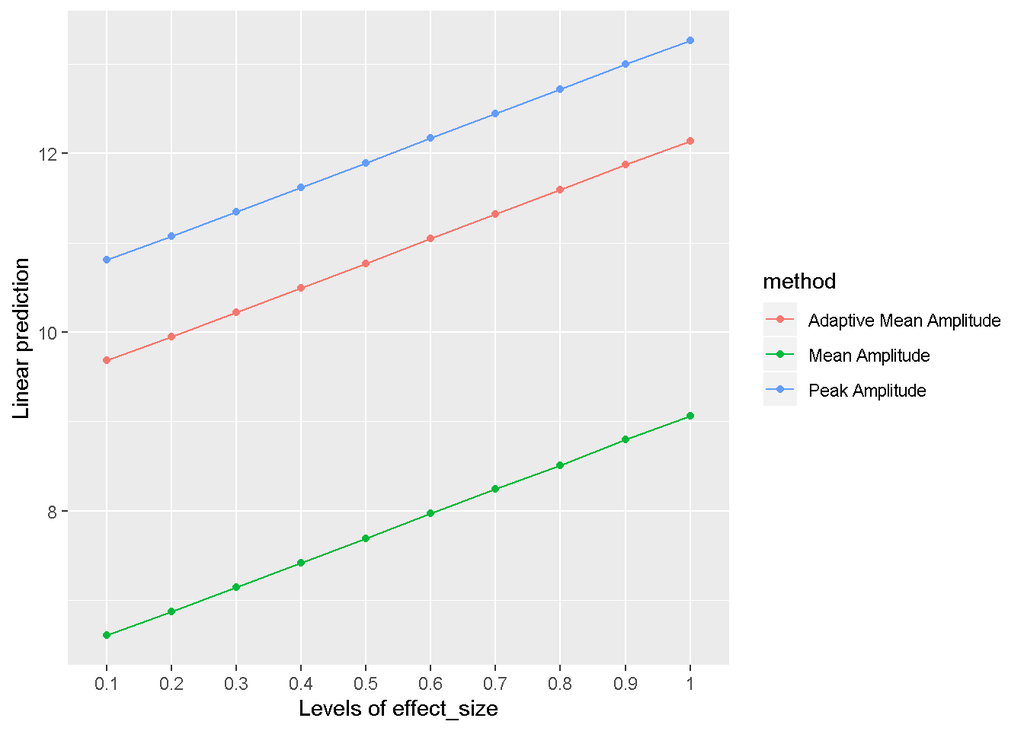

```r
#=========================================#
#POST-HOC TUKEY TESTS AND VISUALIZATIONS
#=========================================#
#This graph indicates that all sample sizes produce similar results for each peak-picking methodology
emmip(model, method ~ effect_size) #No interaction between these three variables
```

## MEAN - POST-HOC PEAK-PICKING METHODOLOGY

```r
#Post-hoc test with just method comparisons
#These statistically significant differences make sense and are in line with what we'd expect to see
post_hoc_model2 = emmeans(
  model,
  pairwise ~ method,
  adjust = "tukey",
  mode = "satterthwaite"
  ) %>%
  summary(infer = TRUE, type = "response")
```

```
## NOTE: Results may be misleading due to involvement in interactions
```

```r
kable(post_hoc_model2[2], #Printing only the comparisons
      caption = "Post-Hoc Methodology Comparisons",
      digits = 4)
```

Post-Hoc Methodology Comparisons

| contrast | estimate | SE | df | lower.CL | upper.CL | t.ratio | p.value |
| --- | --- | --- | --- | --- | --- | --- | --- |
| Adaptive Mean Amplitude - Mean Amplitude | 3.0771 | 0.0017 | 599967 | 3.0731 | 3.0812 | 1801.9306 | 0 |
| Adaptive Mean Amplitude - Peak Amplitude | -1.1248 | 0.0017 | 599967 | -1.1288 | -1.1208 | -658.6581 | 0 |
| Mean Amplitude - Peak Amplitude | -4.2019 | 0.0017 | 599967 | -4.2059 | -4.1979 | -2460.5888 | 0 |

#### Post-hoc methodology visualization

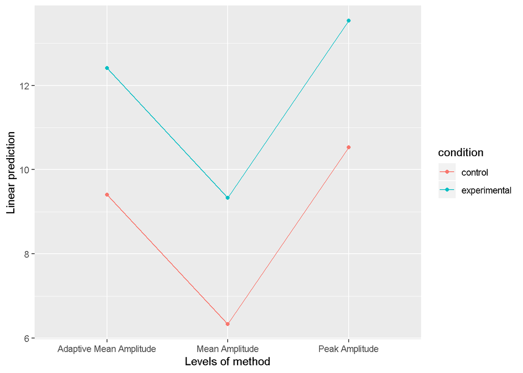

```r
#=========================================#
#POST-HOC TUKEY TESTS AND VISUALIZATIONS
#=========================================#
#This graph indicates that all sample sizes produce similar results for each peak-picking methodology
emmip(model, condition ~ method) #No interaction between these three variables
```

## MEAN - POST-HOC SAMPLE SIZE

```r
#Post-hoc test with just method comparisons
#These statistically significant differences make sense and are in line with what we'd expect to see
post_hoc_model2 = emmeans(
  model,
  pairwise ~ sample_size,
  adjust = "tukey",
  mode = "satterthwaite"
  ) %>%
  summary(infer = TRUE, type = "response")

kable(post_hoc_model2[2], #Printing only the comparisons
      caption = "Post-Hoc sample Size Comparisons",
      digits = 4)
```

Post-Hoc sample Size Comparisons

| contrast | estimate | SE | df | lower.CL | upper.CL | t.ratio | p.value |
| --- | --- | --- | --- | --- | --- | --- | --- |
| 10 - 20 | 0.0020 | 0.0031 | 599967 | -0.0078 | 0.0119 | 0.6560 | 0.9997 |
| 10 - 30 | -0.0037 | 0.0031 | 599967 | -0.0136 | 0.0062 | -1.1881 | 0.9743 |
| 10 - 40 | -0.0092 | 0.0031 | 599967 | -0.0190 | 0.0007 | -2.9384 | 0.0952 |
| 10 - 50 | -0.0062 | 0.0031 | 599967 | -0.0160 | 0.0037 | -1.9798 | 0.6134 |
| 10 - 60 | -0.0031 | 0.0031 | 599967 | -0.0130 | 0.0068 | -0.9976 | 0.9925 |
| 10 - 70 | -0.0031 | 0.0031 | 599967 | -0.0130 | 0.0067 | -1.0026 | 0.9922 |
| 10 - 80 | -0.0027 | 0.0031 | 599967 | -0.0126 | 0.0071 | -0.8736 | 0.9972 |
| 10 - 90 | -0.0035 | 0.0031 | 599967 | -0.0133 | 0.0064 | -1.1109 | 0.9838 |
| 10 - 100 | -0.0031 | 0.0031 | 599967 | -0.0130 | 0.0067 | -1.0034 | 0.9921 |
| 20 - 30 | -0.0057 | 0.0031 | 599967 | -0.0156 | 0.0041 | -1.8441 | 0.7068 |
| 20 - 40 | -0.0112 | 0.0031 | 599967 | -0.0211 | -0.0013 | -3.5944 | 0.0121 |
| 20 - 50 | -0.0082 | 0.0031 | 599967 | -0.0181 | 0.0016 | -2.6359 | 0.2008 |
| 20 - 60 | -0.0052 | 0.0031 | 599967 | -0.0150 | 0.0047 | -1.6536 | 0.8214 |
| 20 - 70 | -0.0052 | 0.0031 | 599967 | -0.0150 | 0.0047 | -1.6586 | 0.8187 |
| 20 - 80 | -0.0048 | 0.0031 | 599967 | -0.0146 | 0.0051 | -1.5296 | 0.8806 |
| 20 - 90 | -0.0055 | 0.0031 | 599967 | -0.0154 | 0.0044 | -1.7669 | 0.7562 |
| 20 - 100 | -0.0052 | 0.0031 | 599967 | -0.0150 | 0.0047 | -1.6594 | 0.8183 |
| 30 - 40 | -0.0055 | 0.0031 | 599967 | -0.0153 | 0.0044 | -1.7503 | 0.7663 |
| 30 - 50 | -0.0025 | 0.0031 | 599967 | -0.0123 | 0.0074 | -0.7917 | 0.9987 |
| 30 - 60 | 0.0006 | 0.0031 | 599967 | -0.0093 | 0.0105 | 0.1905 | 1.0000 |
| 30 - 70 | 0.0006 | 0.0031 | 599967 | -0.0093 | 0.0104 | 0.1855 | 1.0000 |
| 30 - 80 | 0.0010 | 0.0031 | 599967 | -0.0089 | 0.0108 | 0.3145 | 1.0000 |
| 30 - 90 | 0.0002 | 0.0031 | 599967 | -0.0096 | 0.0101 | 0.0772 | 1.0000 |
| 30 - 100 | 0.0006 | 0.0031 | 599967 | -0.0093 | 0.0104 | 0.1847 | 1.0000 |
| 40 - 50 | 0.0030 | 0.0031 | 599967 | -0.0069 | 0.0129 | 0.9586 | 0.9944 |
| 40 - 60 | 0.0061 | 0.0031 | 599967 | -0.0038 | 0.0159 | 1.9409 | 0.6408 |
| 40 - 70 | 0.0060 | 0.0031 | 599967 | -0.0038 | 0.0159 | 1.9359 | 0.6443 |
| 40 - 80 | 0.0064 | 0.0031 | 599967 | -0.0034 | 0.0163 | 2.0648 | 0.5526 |
| 40 - 90 | 0.0057 | 0.0031 | 599967 | -0.0042 | 0.0156 | 1.8275 | 0.7177 |
| 40 - 100 | 0.0060 | 0.0031 | 599967 | -0.0038 | 0.0159 | 1.9350 | 0.6449 |
| 50 - 60 | 0.0031 | 0.0031 | 599967 | -0.0068 | 0.0129 | 0.9823 | 0.9933 |
| 50 - 70 | 0.0030 | 0.0031 | 599967 | -0.0068 | 0.0129 | 0.9773 | 0.9935 |
| 50 - 80 | 0.0034 | 0.0031 | 599967 | -0.0064 | 0.0133 | 1.1062 | 0.9842 |
| 50 - 90 | 0.0027 | 0.0031 | 599967 | -0.0072 | 0.0126 | 0.8689 | 0.9973 |
| 50 - 100 | 0.0030 | 0.0031 | 599967 | -0.0068 | 0.0129 | 0.9764 | 0.9936 |
| 60 - 70 | 0.0000 | 0.0031 | 599967 | -0.0099 | 0.0098 | -0.0050 | 1.0000 |
| 60 - 80 | 0.0004 | 0.0031 | 599967 | -0.0095 | 0.0103 | 0.1240 | 1.0000 |
| 60 - 90 | -0.0004 | 0.0031 | 599967 | -0.0102 | 0.0095 | -0.1133 | 1.0000 |
| 60 - 100 | 0.0000 | 0.0031 | 599967 | -0.0099 | 0.0098 | -0.0059 | 1.0000 |
| 70 - 80 | 0.0004 | 0.0031 | 599967 | -0.0095 | 0.0103 | 0.1289 | 1.0000 |
| 70 - 90 | -0.0003 | 0.0031 | 599967 | -0.0102 | 0.0095 | -0.1083 | 1.0000 |
| 70 - 100 | 0.0000 | 0.0031 | 599967 | -0.0099 | 0.0099 | -0.0009 | 1.0000 |
| 80 - 90 | -0.0007 | 0.0031 | 599967 | -0.0106 | 0.0091 | -0.2373 | 1.0000 |
| 80 - 100 | -0.0004 | 0.0031 | 599967 | -0.0103 | 0.0095 | -0.1298 | 1.0000 |
| 90 - 100 | 0.0003 | 0.0031 | 599967 | -0.0095 | 0.0102 | 0.1075 | 1.0000 |

#### Post-hoc sample size visualization

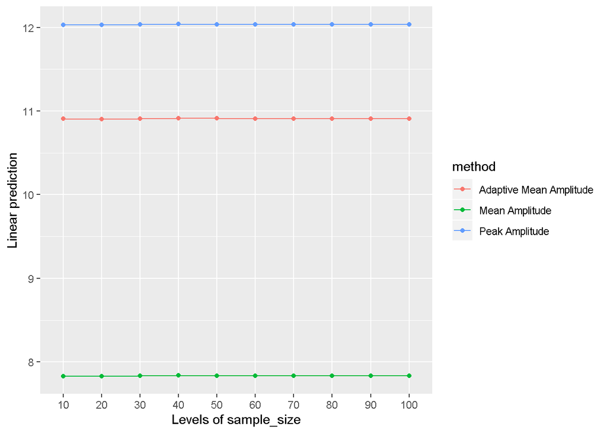

```r
#=========================================#
#POST-HOC TUKEY TESTS AND VISUALIZATIONS
#=========================================#
#This graph indicates that all sample sizes produce similar results for each peak-picking methodology
emmip(model, method ~ sample_size) #No interaction between these three variables
```

## MEAN - POST-HOC CONDITION BY EFFECT SIZE

```r
#Post-hoc test with just method comparisons
#These statistically significant differences make sense and are in line with what we'd expect to see
post_hoc_model2 = emmeans(
  model,
  pairwise ~ condition | effect_size,
  adjust = "tukey",
  mode = "satterthwaite"
  ) %>%
  summary(infer = TRUE, type = "response")

kable(post_hoc_model2[2], #Printing only the comparisons
      caption = "Post-Hoc Condition by Effect Size Comparisons",
      digits = 4)
```

Post-Hoc Condition by Effect Size Comparisons

| contrast | effect_size | estimate | SE | df | lower.CL | upper.CL | t.ratio | p.value |
| --- | --- | --- | --- | --- | --- | --- | --- | --- |
| control - experimental | 0.1 | -0.5467 | 0.0044 | 599967 | -0.5554 | -0.5381 | -123.9993 | 0 |
| control - experimental | 0.2 | -1.0860 | 0.0044 | 599967 | -1.0946 | -1.0774 | -246.3020 | 0 |
| control - experimental | 0.3 | -1.6320 | 0.0044 | 599967 | -1.6407 | -1.6234 | -370.1349 | 0 |
| control - experimental | 0.4 | -2.1752 | 0.0044 | 599967 | -2.1838 | -2.1665 | -493.3225 | 0 |
| control - experimental | 0.5 | -2.7235 | 0.0044 | 599967 | -2.7321 | -2.7148 | -617.6740 | 0 |
| control - experimental | 0.6 | -3.2797 | 0.0044 | 599967 | -3.2883 | -3.2711 | -743.8239 | 0 |
| control - experimental | 0.7 | -3.8160 | 0.0044 | 599967 | -3.8247 | -3.8074 | -865.4563 | 0 |
| control - experimental | 0.8 | -4.3730 | 0.0044 | 599967 | -4.3817 | -4.3644 | -991.7883 | 0 |
| control - experimental | 0.9 | -4.9122 | 0.0044 | 599967 | -4.9208 | -4.9035 | -1114.0635 | 0 |
| control - experimental | 1 | -5.4777 | 0.0044 | 599967 | -5.4864 | -5.4691 | -1242.3307 | 0 |

#### Post-hoc condition by effect size visualizations

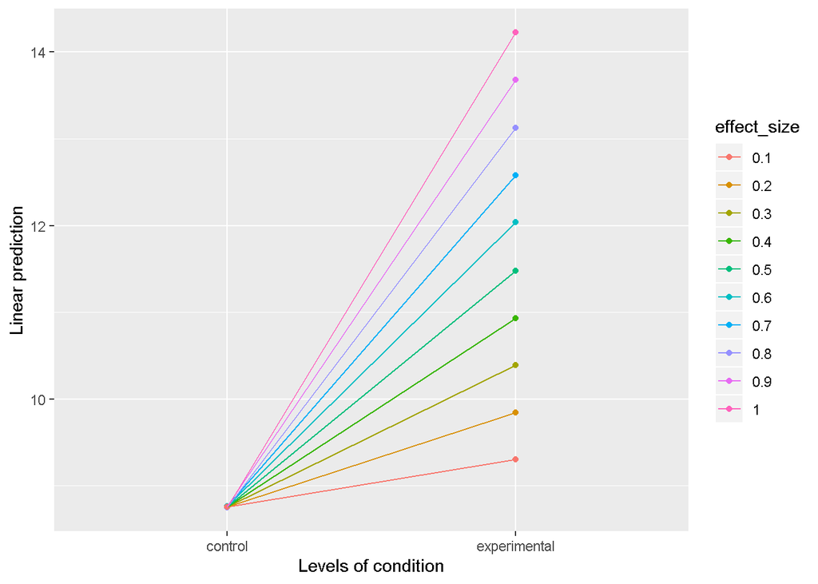

```r
#=========================================#
#POST-HOC TUKEY TESTS AND VISUALIZATIONS
#=========================================#
emmip(model, effect_size ~ condition) #There is an interaction here between condition and effect size
```

Outcomes:

- No interaction between method, sample size, and condition
- Interaction between condition and effect size

# Analyzing the Power

## POWER - ANOVA

Outcomes:

## POWER - POST-HOC EFFECT SIZE

```r
#Post-hoc test with just method comparisons
#These statistically significant differences make sense and are in line with what we'd expect to see
post_hoc_model2 = emmeans(
  model2,
  pairwise ~ effect_size,
  adjust = "tukey",
  mode = "satterthwaite"
  ) %>%
  summary(infer = TRUE, type = "response")
```

```
## NOTE: Results may be misleading due to involvement in interactions
```

```r
kable(post_hoc_model2[2], #Printing only the comparisons
      caption = "Post-Hoc Effect Size Comparisons",
      digits = 4)
```

Post-Hoc Effect Size Comparisons

| contrast | estimate | SE | df | lower.CL | upper.CL | t.ratio | p.value |
| --- | --- | --- | --- | --- | --- | --- | --- |
| 0.1 - 0.2 | 0.1649 | 0.0012 | 299700 | 0.1611 | 0.1687 | 136.6486 | 0.0000 |
| 0.1 - 0.3 | 0.2815 | 0.0012 | 299700 | 0.2777 | 0.2854 | 233.2948 | 0.0000 |
| 0.1 - 0.4 | 0.3362 | 0.0012 | 299700 | 0.3324 | 0.3400 | 278.5768 | 0.0000 |
| 0.1 - 0.5 | 0.3633 | 0.0012 | 299700 | 0.3594 | 0.3671 | 301.0123 | 0.0000 |
| 0.1 - 0.6 | 0.3796 | 0.0012 | 299700 | 0.3757 | 0.3834 | 314.5188 | 0.0000 |
| 0.1 - 0.7 | 0.3857 | 0.0012 | 299700 | 0.3819 | 0.3895 | 319.6007 | 0.0000 |
| 0.1 - 0.8 | 0.3912 | 0.0012 | 299700 | 0.3874 | 0.3950 | 324.1902 | 0.0000 |
| 0.1 - 0.9 | 0.3937 | 0.0012 | 299700 | 0.3898 | 0.3975 | 326.2054 | 0.0000 |
| 0.1 - 1 | 0.3949 | 0.0012 | 299700 | 0.3911 | 0.3987 | 327.2220 | 0.0000 |
| 0.2 - 0.3 | 0.1166 | 0.0012 | 299700 | 0.1128 | 0.1204 | 96.6462 | 0.0000 |
| 0.2 - 0.4 | 0.1713 | 0.0012 | 299700 | 0.1675 | 0.1751 | 141.9282 | 0.0000 |
| 0.2 - 0.5 | 0.1984 | 0.0012 | 299700 | 0.1945 | 0.2022 | 164.3637 | 0.0000 |
| 0.2 - 0.6 | 0.2147 | 0.0012 | 299700 | 0.2108 | 0.2185 | 177.8702 | 0.0000 |
| 0.2 - 0.7 | 0.2208 | 0.0012 | 299700 | 0.2170 | 0.2246 | 182.9521 | 0.0000 |
| 0.2 - 0.8 | 0.2263 | 0.0012 | 299700 | 0.2225 | 0.2301 | 187.5415 | 0.0000 |
| 0.2 - 0.9 | 0.2288 | 0.0012 | 299700 | 0.2249 | 0.2326 | 189.5567 | 0.0000 |
| 0.2 - 1 | 0.2300 | 0.0012 | 299700 | 0.2262 | 0.2338 | 190.5734 | 0.0000 |
| 0.3 - 0.4 | 0.0546 | 0.0012 | 299700 | 0.0508 | 0.0585 | 45.2819 | 0.0000 |
| 0.3 - 0.5 | 0.0817 | 0.0012 | 299700 | 0.0779 | 0.0855 | 67.7175 | 0.0000 |
| 0.3 - 0.6 | 0.0980 | 0.0012 | 299700 | 0.0942 | 0.1018 | 81.2239 | 0.0000 |
| 0.3 - 0.7 | 0.1042 | 0.0012 | 299700 | 0.1003 | 0.1080 | 86.3058 | 0.0000 |
| 0.3 - 0.8 | 0.1097 | 0.0012 | 299700 | 0.1059 | 0.1135 | 90.8953 | 0.0000 |
| 0.3 - 0.9 | 0.1121 | 0.0012 | 299700 | 0.1083 | 0.1159 | 92.9105 | 0.0000 |
| 0.3 - 1 | 0.1134 | 0.0012 | 299700 | 0.1095 | 0.1172 | 93.9272 | 0.0000 |
| 0.4 - 0.5 | 0.0271 | 0.0012 | 299700 | 0.0233 | 0.0309 | 22.4355 | 0.0000 |
| 0.4 - 0.6 | 0.0434 | 0.0012 | 299700 | 0.0396 | 0.0472 | 35.9420 | 0.0000 |
| 0.4 - 0.7 | 0.0495 | 0.0012 | 299700 | 0.0457 | 0.0533 | 41.0239 | 0.0000 |
| 0.4 - 0.8 | 0.0550 | 0.0012 | 299700 | 0.0512 | 0.0589 | 45.6134 | 0.0000 |
| 0.4 - 0.9 | 0.0575 | 0.0012 | 299700 | 0.0537 | 0.0613 | 47.6286 | 0.0000 |
| 0.4 - 1 | 0.0587 | 0.0012 | 299700 | 0.0549 | 0.0625 | 48.6453 | 0.0000 |
| 0.5 - 0.6 | 0.0163 | 0.0012 | 299700 | 0.0125 | 0.0201 | 13.5064 | 0.0000 |
| 0.5 - 0.7 | 0.0224 | 0.0012 | 299700 | 0.0186 | 0.0263 | 18.5883 | 0.0000 |
| 0.5 - 0.8 | 0.0280 | 0.0012 | 299700 | 0.0242 | 0.0318 | 23.1778 | 0.0000 |
| 0.5 - 0.9 | 0.0304 | 0.0012 | 299700 | 0.0266 | 0.0342 | 25.1930 | 0.0000 |
| 0.5 - 1 | 0.0316 | 0.0012 | 299700 | 0.0278 | 0.0354 | 26.2097 | 0.0000 |
| 0.6 - 0.7 | 0.0061 | 0.0012 | 299700 | 0.0023 | 0.0100 | 5.0819 | 0.0000 |
| 0.6 - 0.8 | 0.0117 | 0.0012 | 299700 | 0.0079 | 0.0155 | 9.6714 | 0.0000 |
| 0.6 - 0.9 | 0.0141 | 0.0012 | 299700 | 0.0103 | 0.0179 | 11.6866 | 0.0000 |
| 0.6 - 1 | 0.0153 | 0.0012 | 299700 | 0.0115 | 0.0191 | 12.7033 | 0.0000 |
| 0.7 - 0.8 | 0.0055 | 0.0012 | 299700 | 0.0017 | 0.0094 | 4.5895 | 0.0002 |
| 0.7 - 0.9 | 0.0080 | 0.0012 | 299700 | 0.0042 | 0.0118 | 6.6047 | 0.0000 |
| 0.7 - 1 | 0.0092 | 0.0012 | 299700 | 0.0054 | 0.0130 | 7.6214 | 0.0000 |
| 0.8 - 0.9 | 0.0024 | 0.0012 | 299700 | -0.0014 | 0.0062 | 2.0152 | 0.5882 |
| 0.8 - 1 | 0.0037 | 0.0012 | 299700 | -0.0002 | 0.0075 | 3.0319 | 0.0735 |
| 0.9 - 1 | 0.0012 | 0.0012 | 299700 | -0.0026 | 0.0050 | 1.0167 | 0.9914 |

## POWER - POST-HOC SAMPLE SIZE

```r
#Post-hoc test with just method comparisons
#These statistically significant differences make sense and are in line with what we'd expect to see
post_hoc_model2 = emmeans(
  model2,
  pairwise ~ sample_size,
  adjust = "tukey",
  mode = "satterthwaite"
  ) %>%
  summary(infer = TRUE, type = "response")
```

```
## NOTE: Results may be misleading due to involvement in interactions
```

```r
kable(post_hoc_model2[2], #Printing only the comparisons
      caption = "Post-Hoc Effect Size Comparisons",
      digits = 4)
```

| contrast | estimate | SE | df | lower.CL | upper.CL | t.ratio | p.value |
| --- | --- | --- | --- | --- | --- | --- | --- |
| 10 - 20 | 0.0677 | 0.0012 | 299700 | 0.0639 | 0.0715 | 56.0906 | 0.0000 |
| 10 - 30 | 0.0988 | 0.0012 | 299700 | 0.0949 | 0.1026 | 81.8385 | 0.0000 |
| 10 - 40 | 0.1166 | 0.0012 | 299700 | 0.1128 | 0.1204 | 96.6045 | 0.0000 |
| 10 - 50 | 0.1280 | 0.0012 | 299700 | 0.1242 | 0.1318 | 106.0767 | 0.0000 |
| 10 - 60 | 0.1372 | 0.0012 | 299700 | 0.1334 | 0.1411 | 113.7200 | 0.0000 |
| 10 - 70 | 0.1437 | 0.0012 | 299700 | 0.1398 | 0.1475 | 119.0484 | 0.0000 |
| 10 - 80 | 0.1506 | 0.0012 | 299700 | 0.1467 | 0.1544 | 124.7651 | 0.0000 |
| 10 - 90 | 0.1559 | 0.0012 | 299700 | 0.1521 | 0.1597 | 129.1872 | 0.0000 |
| 10 - 100 | 0.1580 | 0.0012 | 299700 | 0.1542 | 0.1618 | 130.9317 | 0.0000 |
| 20 - 30 | 0.0311 | 0.0012 | 299700 | 0.0273 | 0.0349 | 25.7479 | 0.0000 |
| 20 - 40 | 0.0489 | 0.0012 | 299700 | 0.0451 | 0.0527 | 40.5139 | 0.0000 |
| 20 - 50 | 0.0603 | 0.0012 | 299700 | 0.0565 | 0.0641 | 49.9861 | 0.0000 |
| 20 - 60 | 0.0695 | 0.0012 | 299700 | 0.0657 | 0.0734 | 57.6295 | 0.0000 |
| 20 - 70 | 0.0760 | 0.0012 | 299700 | 0.0722 | 0.0798 | 62.9578 | 0.0000 |
| 20 - 80 | 0.0829 | 0.0012 | 299700 | 0.0791 | 0.0867 | 68.6746 | 0.0000 |
| 20 - 90 | 0.0882 | 0.0012 | 299700 | 0.0844 | 0.0920 | 73.0966 | 0.0000 |
| 20 - 100 | 0.0903 | 0.0012 | 299700 | 0.0865 | 0.0941 | 74.8411 | 0.0000 |
| 30 - 40 | 0.0178 | 0.0012 | 299700 | 0.0140 | 0.0216 | 14.7659 | 0.0000 |
| 30 - 50 | 0.0293 | 0.0012 | 299700 | 0.0254 | 0.0331 | 24.2382 | 0.0000 |
| 30 - 60 | 0.0385 | 0.0012 | 299700 | 0.0347 | 0.0423 | 31.8815 | 0.0000 |
| 30 - 70 | 0.0449 | 0.0012 | 299700 | 0.0411 | 0.0487 | 37.2099 | 0.0000 |
| 30 - 80 | 0.0518 | 0.0012 | 299700 | 0.0480 | 0.0556 | 42.9266 | 0.0000 |
| 30 - 90 | 0.0571 | 0.0012 | 299700 | 0.0533 | 0.0610 | 47.3487 | 0.0000 |
| 30 - 100 | 0.0592 | 0.0012 | 299700 | 0.0554 | 0.0631 | 49.0932 | 0.0000 |
| 40 - 50 | 0.0114 | 0.0012 | 299700 | 0.0076 | 0.0152 | 9.4722 | 0.0000 |
| 40 - 60 | 0.0207 | 0.0012 | 299700 | 0.0168 | 0.0245 | 17.1156 | 0.0000 |
| 40 - 70 | 0.0271 | 0.0012 | 299700 | 0.0233 | 0.0309 | 22.4439 | 0.0000 |
| 40 - 80 | 0.0340 | 0.0012 | 299700 | 0.0302 | 0.0378 | 28.1607 | 0.0000 |
| 40 - 90 | 0.0393 | 0.0012 | 299700 | 0.0355 | 0.0431 | 32.5827 | 0.0000 |
| 40 - 100 | 0.0414 | 0.0012 | 299700 | 0.0376 | 0.0452 | 34.3272 | 0.0000 |
| 50 - 60 | 0.0092 | 0.0012 | 299700 | 0.0054 | 0.0130 | 7.6433 | 0.0000 |
| 50 - 70 | 0.0157 | 0.0012 | 299700 | 0.0118 | 0.0195 | 12.9717 | 0.0000 |
| 50 - 80 | 0.0226 | 0.0012 | 299700 | 0.0187 | 0.0264 | 18.6884 | 0.0000 |
| 50 - 90 | 0.0279 | 0.0012 | 299700 | 0.0241 | 0.0317 | 23.1105 | 0.0000 |
| 50 - 100 | 0.0300 | 0.0012 | 299700 | 0.0262 | 0.0338 | 24.8550 | 0.0000 |
| 60 - 70 | 0.0064 | 0.0012 | 299700 | 0.0026 | 0.0102 | 5.3283 | 0.0000 |
| 60 - 80 | 0.0133 | 0.0012 | 299700 | 0.0095 | 0.0171 | 11.0451 | 0.0000 |
| 60 - 90 | 0.0187 | 0.0012 | 299700 | 0.0148 | 0.0225 | 15.4672 | 0.0000 |
| 60 - 100 | 0.0208 | 0.0012 | 299700 | 0.0170 | 0.0246 | 17.2116 | 0.0000 |
| 70 - 80 | 0.0069 | 0.0012 | 299700 | 0.0031 | 0.0107 | 5.7168 | 0.0000 |
| 70 - 90 | 0.0122 | 0.0012 | 299700 | 0.0084 | 0.0161 | 10.1388 | 0.0000 |
| 70 - 100 | 0.0143 | 0.0012 | 299700 | 0.0105 | 0.0182 | 11.8833 | 0.0000 |
| 80 - 90 | 0.0053 | 0.0012 | 299700 | 0.0015 | 0.0092 | 4.4221 | 0.0004 |
| 80 - 100 | 0.0074 | 0.0012 | 299700 | 0.0036 | 0.0113 | 6.1665 | 0.0000 |
| 90 - 100 | 0.0021 | 0.0012 | 299700 | -0.0017 | 0.0059 | 1.7445 | 0.7699 |

## POWER - POST-HOC EFFECT SIZE BY PEAK-PICKING METHODOLOGY

```r
#Post-hoc test with just method comparisons
#These statistically significant differences make sense and are in line with what we'd expect to see
post_hoc_model2 = emmeans(
  model2,
  pairwise ~ method | effect_size,
  adjust = "tukey",
  mode = "satterthwaite"
  ) %>%
  summary(infer = TRUE, type = "response")
```

```
## NOTE: Results may be misleading due to involvement in interactions
```

```r
#Reformatting the output with kable to make a nicer table
kable(post_hoc_model2[2], #Printing only the comparisons
      caption = "Post-Hoc Effect Size and Methodology Comparisons",
      digits = 4)
```

Post-Hoc Effect Size and Methodology Comparisons

| contrast | effect_size | estimate | SE | df | lower.CL | upper.CL | t.ratio | p.value |
| --- | --- | --- | --- | --- | --- | --- | --- | --- |
| adapative mean - mean | 0.1 | 0.0438 | 0.0021 | 299700 | 0.0389 | 0.0487 | 20.9338 | 0.0000 |
| adapative mean - peak | 0.1 | -0.0048 | 0.0021 | 299700 | -0.0097 | 0.0001 | -2.2837 | 0.0581 |
| mean - peak | 0.1 | -0.0485 | 0.0021 | 299700 | -0.0534 | -0.0436 | -23.2175 | 0.0000 |
| adapative mean - mean | 0.2 | 0.0787 | 0.0021 | 299700 | 0.0738 | 0.0836 | 37.6365 | 0.0000 |
| adapative mean - peak | 0.2 | -0.0056 | 0.0021 | 299700 | -0.0105 | -0.0007 | -2.6961 | 0.0192 |
| mean - peak | 0.2 | -0.0843 | 0.0021 | 299700 | -0.0892 | -0.0794 | -40.3326 | 0.0000 |
| adapative mean - mean | 0.3 | 0.0565 | 0.0021 | 299700 | 0.0516 | 0.0614 | 27.0492 | 0.0000 |
| adapative mean - peak | 0.3 | -0.0066 | 0.0021 | 299700 | -0.0115 | -0.0017 | -3.1508 | 0.0046 |
| mean - peak | 0.3 | -0.0631 | 0.0021 | 299700 | -0.0680 | -0.0582 | -30.2000 | 0.0000 |
| adapative mean - mean | 0.4 | 0.0343 | 0.0021 | 299700 | 0.0294 | 0.0392 | 16.4256 | 0.0000 |
| adapative mean - peak | 0.4 | -0.0038 | 0.0021 | 299700 | -0.0087 | 0.0011 | -1.7964 | 0.1708 |
| mean - peak | 0.4 | -0.0381 | 0.0021 | 299700 | -0.0430 | -0.0332 | -18.2220 | 0.0000 |
| adapative mean - mean | 0.5 | 0.0218 | 0.0021 | 299700 | 0.0169 | 0.0267 | 10.4360 | 0.0000 |
| adapative mean - peak | 0.5 | -0.0027 | 0.0021 | 299700 | -0.0076 | 0.0022 | -1.2973 | 0.3967 |
| mean - peak | 0.5 | -0.0245 | 0.0021 | 299700 | -0.0294 | -0.0196 | -11.7333 | 0.0000 |
| adapative mean - mean | 0.6 | 0.0129 | 0.0021 | 299700 | 0.0080 | 0.0178 | 6.1642 | 0.0000 |
| adapative mean - peak | 0.6 | -0.0014 | 0.0021 | 299700 | -0.0063 | 0.0035 | -0.6612 | 0.7860 |
| mean - peak | 0.6 | -0.0143 | 0.0021 | 299700 | -0.0192 | -0.0094 | -6.8254 | 0.0000 |
| adapative mean - mean | 0.7 | 0.0088 | 0.0021 | 299700 | 0.0039 | 0.0137 | 4.2089 | 0.0001 |
| adapative mean - peak | 0.7 | -0.0013 | 0.0021 | 299700 | -0.0062 | 0.0036 | -0.6212 | 0.8085 |
| mean - peak | 0.7 | -0.0101 | 0.0021 | 299700 | -0.0150 | -0.0052 | -4.8301 | 0.0000 |
| adapative mean - mean | 0.8 | 0.0052 | 0.0021 | 299700 | 0.0003 | 0.0101 | 2.4680 | 0.0362 |
| adapative mean - peak | 0.8 | -0.0010 | 0.0021 | 299700 | -0.0059 | 0.0039 | -0.4566 | 0.8915 |
| mean - peak | 0.8 | -0.0061 | 0.0021 | 299700 | -0.0110 | -0.0012 | -2.9246 | 0.0097 |
| adapative mean - mean | 0.9 | 0.0033 | 0.0021 | 299700 | -0.0016 | 0.0082 | 1.5564 | 0.2648 |
| adapative mean - peak | 0.9 | -0.0005 | 0.0021 | 299700 | -0.0054 | 0.0044 | -0.2591 | 0.9637 |
| mean - peak | 0.9 | -0.0038 | 0.0021 | 299700 | -0.0087 | 0.0011 | -1.8155 | 0.1645 |
| adapative mean - mean | 1 | 0.0023 | 0.0021 | 299700 | -0.0026 | 0.0072 | 1.0860 | 0.5228 |
| adapative mean - peak | 1 | -0.0002 | 0.0021 | 299700 | -0.0051 | 0.0047 | -0.1090 | 0.9935 |
| mean - peak | 1 | -0.0025 | 0.0021 | 299700 | -0.0074 | 0.0024 | -1.1949 | 0.4562 |

```
## NOTE: Results may be misleading due to involvement in interactions
```

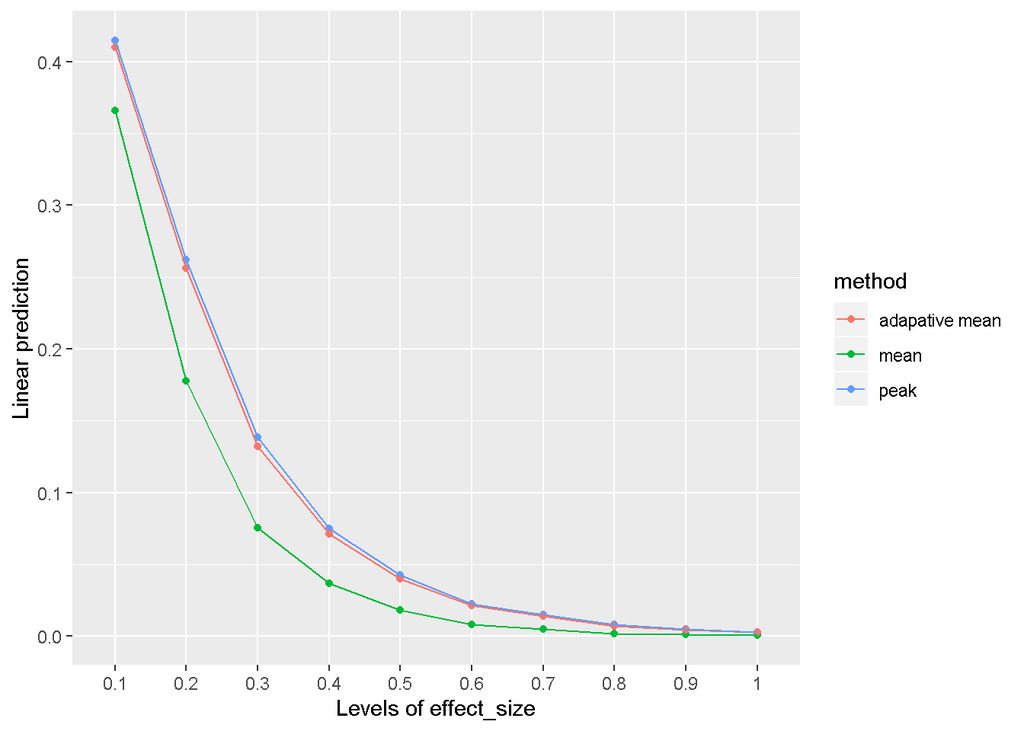

```r
#Graphing the methodology by effect size
emmip(model2, method ~ effect_size) #No interaction between these three variables
```

## POWER - POST-HOC SAMPLE SIZE BY PEAK-PICKING METHODOLOGY

```r
#Post-hoc test with just method comparisons
#These statistically significant differences make sense and are in line with what we'd expect to see
post_hoc_model2 = emmeans(
  model2,
  pairwise ~ method | sample_size,
  adjust = "tukey",
  mode = "satterthwaite"
  ) %>%
  summary(infer = TRUE, type = "response")
```

```
## NOTE: Results may be misleading due to involvement in interactions
```

```r
kable(post_hoc_model2[2], #Printing only the comparisons
      caption = "Post-Hoc Effect Size and Sample Size Comparisons",
      digits = 4)
```

| contrast | sample_size | estimate | SE | df | lower.CL | upper.CL | t.ratio | p.value |
| --- | --- | --- | --- | --- | --- | --- | --- | --- |
| adapative mean - mean | 10 | 0.0532 | 0.0021 | 299700 | 0.0483 | 0.0581 | 25.4440 | 0.0000 |
| adapative mean - peak | 10 | -0.0048 | 0.0021 | 299700 | -0.0097 | 0.0001 | -2.2779 | 0.0589 |
| mean - peak | 10 | -0.0579 | 0.0021 | 299700 | -0.0628 | -0.0530 | -27.7219 | 0.0000 |
| adapative mean - mean | 20 | 0.0380 | 0.0021 | 299700 | 0.0331 | 0.0429 | 18.1866 | 0.0000 |
| adapative mean - peak | 20 | -0.0033 | 0.0021 | 299700 | -0.0082 | 0.0016 | -1.5624 | 0.2621 |
| mean - peak | 20 | -0.0413 | 0.0021 | 299700 | -0.0462 | -0.0364 | -19.7490 | 0.0000 |
| adapative mean - mean | 30 | 0.0305 | 0.0021 | 299700 | 0.0256 | 0.0354 | 14.6062 | 0.0000 |
| adapative mean - peak | 30 | -0.0036 | 0.0021 | 299700 | -0.0085 | 0.0013 | -1.7050 | 0.2033 |
| mean - peak | 30 | -0.0341 | 0.0021 | 299700 | -0.0390 | -0.0292 | -16.3112 | 0.0000 |
| adapative mean - mean | 40 | 0.0266 | 0.0021 | 299700 | 0.0217 | 0.0315 | 12.7367 | 0.0000 |
| adapative mean - peak | 40 | -0.0037 | 0.0021 | 299700 | -0.0086 | 0.0012 | -1.7502 | 0.1867 |
| mean - peak | 40 | -0.0303 | 0.0021 | 299700 | -0.0352 | -0.0254 | -14.4869 | 0.0000 |
| adapative mean - mean | 50 | 0.0242 | 0.0021 | 299700 | 0.0193 | 0.0291 | 11.5675 | 0.0000 |
| adapative mean - peak | 50 | -0.0029 | 0.0021 | 299700 | -0.0077 | 0.0020 | -1.3639 | 0.3600 |
| mean - peak | 50 | -0.0270 | 0.0021 | 299700 | -0.0319 | -0.0221 | -12.9314 | 0.0000 |
| adapative mean - mean | 60 | 0.0215 | 0.0021 | 299700 | 0.0166 | 0.0264 | 10.2841 | 0.0000 |
| adapative mean - peak | 60 | -0.0021 | 0.0021 | 299700 | -0.0070 | 0.0028 | -1.0074 | 0.5722 |
| mean - peak | 60 | -0.0236 | 0.0021 | 299700 | -0.0285 | -0.0187 | -11.2915 | 0.0000 |
| adapative mean - mean | 70 | 0.0202 | 0.0021 | 299700 | 0.0153 | 0.0251 | 9.6819 | 0.0000 |
| adapative mean - peak | 70 | -0.0018 | 0.0021 | 299700 | -0.0067 | 0.0031 | -0.8619 | 0.6643 |
| mean - peak | 70 | -0.0220 | 0.0021 | 299700 | -0.0269 | -0.0171 | -10.5438 | 0.0000 |
| adapative mean - mean | 80 | 0.0199 | 0.0021 | 299700 | 0.0150 | 0.0248 | 9.4984 | 0.0000 |
| adapative mean - peak | 80 | -0.0014 | 0.0021 | 299700 | -0.0063 | 0.0035 | -0.6692 | 0.7814 |
| mean - peak | 80 | -0.0213 | 0.0021 | 299700 | -0.0262 | -0.0164 | -10.1676 | 0.0000 |
| adapative mean - mean | 90 | 0.0167 | 0.0021 | 299700 | 0.0118 | 0.0216 | 7.9939 | 0.0000 |
| adapative mean - peak | 90 | -0.0021 | 0.0021 | 299700 | -0.0070 | 0.0028 | -1.0054 | 0.5734 |
| mean - peak | 90 | -0.0188 | 0.0021 | 299700 | -0.0237 | -0.0139 | -8.9993 | 0.0000 |
| adapative mean - mean | 100 | 0.0166 | 0.0021 | 299700 | 0.0118 | 0.0215 | 7.9653 | 0.0000 |
| adapative mean - peak | 100 | -0.0024 | 0.0021 | 299700 | -0.0073 | 0.0025 | -1.1279 | 0.4968 |
| mean - peak | 100 | -0.0190 | 0.0021 | 299700 | -0.0239 | -0.0141 | -9.0932 | 0.0000 |

```
## NOTE: Results may be misleading due to involvement in interactions
```

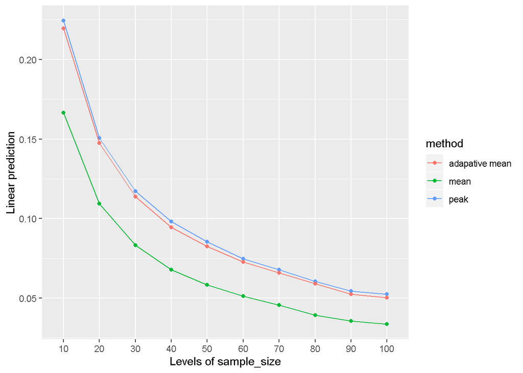

```r
#Graphing the methoodlogy by sample size
emmip(model2, method ~ sample_size)
```

## POWER - POST-HOC THREE-WAY INTERACTION

```r
#Post-hoc test with just method comparisons
#These statistically significant differences make sense and are in line with what we'd expect to see
post_hoc_model2 = emmeans(
  model2,
  pairwise ~ effect_size | method | sample_size,
  adjust = "tukey",
  mode = "satterthwaite"
  ) %>%
  summary(infer = TRUE, type = "response")

#Print a nice;y formatted table
kable(post_hoc_model2[2], #Printing only the comparisons
      caption = "Post-Hoc Effect Size and Sample Size Comparisons",
      digits = 4)
```

Post-Hoc Effect Size and Sample Size Comparisons

| contrast | method | sample_size | estimate | SE | df | lower.CL | upper.CL | t.ratio | p.value |
| --- | --- | --- | --- | --- | --- | --- | --- | --- | --- |
| 0.1 - 0.2 | adapative mean | 10 | 0.0503 | 0.0066 | 299700 | 0.0294 | 0.0713 | 7.6164 | 0.0000 |
| 0.1 - 0.3 | adapative mean | 10 | 0.1183 | 0.0066 | 299700 | 0.0974 | 0.1392 | 17.8947 | 0.0000 |
| 0.1 - 0.4 | adapative mean | 10 | 0.1872 | 0.0066 | 299700 | 0.1663 | 0.2081 | 28.3177 | 0.0000 |
| 0.1 - 0.5 | adapative mean | 10 | 0.2568 | 0.0066 | 299700 | 0.2359 | 0.2777 | 38.8471 | 0.0000 |
| 0.1 - 0.6 | adapative mean | 10 | 0.3354 | 0.0066 | 299700 | 0.3145 | 0.3563 | 50.7423 | 0.0000 |
| 0.1 - 0.7 | adapative mean | 10 | 0.3778 | 0.0066 | 299700 | 0.3569 | 0.3988 | 57.1639 | 0.0000 |
| 0.1 - 0.8 | adapative mean | 10 | 0.4240 | 0.0066 | 299700 | 0.4030 | 0.4449 | 64.1401 | 0.0000 |
| 0.1 - 0.9 | adapative mean | 10 | 0.4478 | 0.0066 | 299700 | 0.4269 | 0.4687 | 67.7474 | 0.0000 |
| 0.1 - 1 | adapative mean | 10 | 0.4598 | 0.0066 | 299700 | 0.4388 | 0.4807 | 69.5553 | 0.0000 |
| 0.2 - 0.3 | adapative mean | 10 | 0.0679 | 0.0066 | 299700 | 0.0470 | 0.0888 | 10.2783 | 0.0000 |
| 0.2 - 0.4 | adapative mean | 10 | 0.1368 | 0.0066 | 299700 | 0.1159 | 0.1577 | 20.7013 | 0.0000 |
| 0.2 - 0.5 | adapative mean | 10 | 0.2064 | 0.0066 | 299700 | 0.1855 | 0.2273 | 31.2307 | 0.0000 |
| 0.2 - 0.6 | adapative mean | 10 | 0.2851 | 0.0066 | 299700 | 0.2641 | 0.3060 | 43.1259 | 0.0000 |
| 0.2 - 0.7 | adapative mean | 10 | 0.3275 | 0.0066 | 299700 | 0.3066 | 0.3484 | 49.5475 | 0.0000 |
| 0.2 - 0.8 | adapative mean | 10 | 0.3736 | 0.0066 | 299700 | 0.3527 | 0.3945 | 56.5237 | 0.0000 |
| 0.2 - 0.9 | adapative mean | 10 | 0.3975 | 0.0066 | 299700 | 0.3765 | 0.4184 | 60.1310 | 0.0000 |
| 0.2 - 1 | adapative mean | 10 | 0.4094 | 0.0066 | 299700 | 0.3885 | 0.4303 | 61.9388 | 0.0000 |
| 0.3 - 0.4 | adapative mean | 10 | 0.0689 | 0.0066 | 299700 | 0.0480 | 0.0898 | 10.4230 | 0.0000 |
| 0.3 - 0.5 | adapative mean | 10 | 0.1385 | 0.0066 | 299700 | 0.1176 | 0.1594 | 20.9524 | 0.0000 |
| 0.3 - 0.6 | adapative mean | 10 | 0.2171 | 0.0066 | 299700 | 0.1962 | 0.2380 | 32.8477 | 0.0000 |
| 0.3 - 0.7 | adapative mean | 10 | 0.2596 | 0.0066 | 299700 | 0.2387 | 0.2805 | 39.2692 | 0.0000 |
| 0.3 - 0.8 | adapative mean | 10 | 0.3057 | 0.0066 | 299700 | 0.2848 | 0.3266 | 46.2454 | 0.0000 |
| 0.3 - 0.9 | adapative mean | 10 | 0.3295 | 0.0066 | 299700 | 0.3086 | 0.3504 | 49.8527 | 0.0000 |
| 0.3 - 1 | adapative mean | 10 | 0.3415 | 0.0066 | 299700 | 0.3206 | 0.3624 | 51.6606 | 0.0000 |
| 0.4 - 0.5 | adapative mean | 10 | 0.0696 | 0.0066 | 299700 | 0.0487 | 0.0905 | 10.5294 | 0.0000 |
| 0.4 - 0.6 | adapative mean | 10 | 0.1482 | 0.0066 | 299700 | 0.1273 | 0.1691 | 22.4246 | 0.0000 |
| 0.4 - 0.7 | adapative mean | 10 | 0.1907 | 0.0066 | 299700 | 0.1698 | 0.2116 | 28.8462 | 0.0000 |
| 0.4 - 0.8 | adapative mean | 10 | 0.2368 | 0.0066 | 299700 | 0.2159 | 0.2577 | 35.8224 | 0.0000 |
| 0.4 - 0.9 | adapative mean | 10 | 0.2606 | 0.0066 | 299700 | 0.2397 | 0.2815 | 39.4297 | 0.0000 |
| 0.4 - 1 | adapative mean | 10 | 0.2726 | 0.0066 | 299700 | 0.2517 | 0.2935 | 41.2376 | 0.0000 |

[output cut: 1320 more lines]

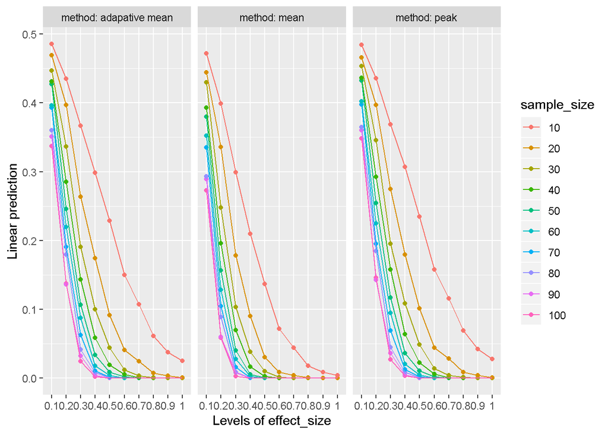

```r
#Graphing the 3-way interaction
emmip(model2,  sample_size ~ effect_size | method) #There is an interaction here between condition and effect size
```

## CONCLUSIONS

- P3 amplitude means are larger in the experimental condition compared to the control
- P3 amplitude means differ among peak-picking methodologies
- Peak methodology produces the largest P3 amplitudes, followed by the adaptive mean and mean methodologies
- P3 amplitudes in the experimental condition increase as effect size increases
- P3 amplitude means are similar across sample sizes
- Power increases as effect sizes increases
- Power increases as sample size increases
- Peak-picking methodologies power seems to differ at lower effect sizes and converges as the effect size becomes larger
- The mean methodology’s power differs from the peak and adaptive mean’s across sample sizes
- The mean methodology’s power appears to be consistently higher
- A peak-picking methodologies power will increase faster when sample size and effect size rise

```r
# rmarkdown::render(paste0(
#       "C:/Users/rjobrien/Desktop/Thesis Code/",
#       "2-Type_II_Error_Simulation_Statistics_Report.Rmd"
#     ))
```